# FORECASTING FINAL PROJECT

### 4.0.4 **Conclusion:**

This cross-validation analysis effectively demonstrates how different models perform in predicting construction spending. The Prophet and ARIMA models show strong predictive capability, while the naïve model struggles. This insight helps in selecting the most robust forecasting approach for future predictions.

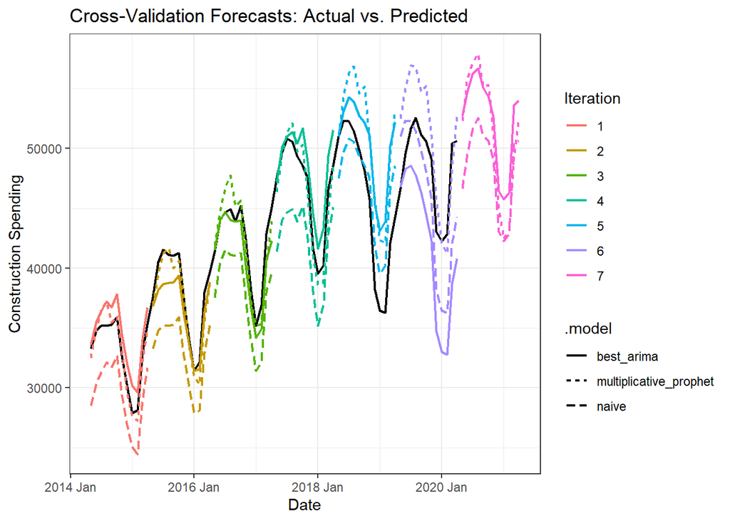

```r
# Convert to tibble and join with actual training data
cv_forecasts %>%
  as_tibble() %>%
  select(-construction_spending) %>%  # Remove duplicate actual value column if present
  left_join(data_train, by = "date") %>%  # Join with actual data on date
  ggplot() +
  geom_line(aes(x = date, y = construction_spending), color = "black", size = 0.8) +  # Actual values
  geom_line(aes(x = date, y = .mean, color = factor(.id), linetype = .model), size = 0.8) +  # Forecasted values
  scale_color_discrete(name = "Iteration") +
  ylab("Construction Spending") +
  xlab("Date") +
  theme_bw() +
  labs(title = "Cross-Validation Forecasts: Actual vs. Predicted")
```

This plot presents the results of a **cross-validation forecast comparison** using three different models—**Best ARIMA, Multiplicative Prophet, and Naïve Model**—over multiple iterations. The black solid line represents the actual observed **construction spending**, while the dashed lines in different colors correspond to the forecasted values from each model across **seven cross-validation iterations**.